# Análise Exploratória - Classificação das melhores lojas no mês atual

Beatriz

## 1. Carregamento e preparação dos dados

### Carregamento das bibliotecas

```r
library(tidyverse)
library(GGally)
```

```r
library(corrplot)
library(gridExtra)
library(readxl)
library(FactoMineR)
library(factoextra)
library(dplyr)
```

### Carregamento dos dados e visualização das primeiras linhas

```r
transaction_faction_v3_2024 <- read.csv(file = './database-projeto-M11/transactions/transaction_fact_v3_2024.csv')

# Exibir primeiras linhas

head(transaction_faction_v3_2024)
```

|  | data | cod_vendedor | cod_loja | cod_transacao | quantidade | cod_prod | preco |
| --- | --- | --- | --- | --- | --- | --- | --- |
| 1 | 2024-05-29 | 917 | SP Capital Centro_48 | 000484fc7c | 1 | 917845373827 | 88.60280 |
| 2 | 2024-05-31 | 58 | SP Capital Centro_99 | 0012fb5659 | 2 | 705516174930 | 123.62559 |
| 3 | 2024-05-31 | 58 | SP Capital Centro_99 | 0012fb5659 | 1 | 715775125765 | 66.96472 |
| 4 | 2024-05-31 | 287 | SP Interior_32 | 001af83ace | 1 | 336847961663 | 66.96472 |
| 5 | 2024-05-30 | 371 | SP Capital Centro_11 | 0026881cb2 | 2 | 426037160751 | 144.23329 |
| 6 | 2024-05-29 | 534 | RJ_57 | 003449351c | 4 | 814394039436 | 440.96355 |

```r
dados1 <- read.csv(file = './database-projeto-M11/transactions/2024-1.csv')

# Exibir primeiras linhas

head(dados1)
```

|  | data | cod_vendedor | cod_loja | cod_transacao | quantidade | cod_prod | preco |
| --- | --- | --- | --- | --- | --- | --- | --- |
| 1 | 2024-05-31 | 239 | SP Capital Sul_18 | 0003c03474 | 7 | 711147737185 | 370.27306 |
| 2 | 2024-05-30 | 145 | RJ_31 | 000a0cb29f | 5 | 217674649903 | 176.30504 |
| 3 | 2024-05-29 | 909 | SP Capital Leste/Oeste_58 | 000a114a81 | 4 | 761888570923 | 181.88331 |
| 4 | 2024-05-29 | 909 | SP Capital Leste/Oeste_58 | 000a114a81 | 8 | 851717490895 | 356.34130 |
| 5 | 2024-05-30 | 240 | SC_30 | 000a8aa0be | 1 | 120545844331 | 29.69201 |
| 6 | 2024-05-29 | 697 | RS_16 | 000b7a8be7 | 2 | 721972741868 | 96.51065 |

### Verificação da estrutura de dados

```r
str(transaction_faction_v3_2024)
```

```
## 'data.frame':    290525 obs. of  7 variables:
##  $ data         : chr  "2024-05-29" "2024-05-31" "2024-05-31" "2024-05-31" ...
##  $ cod_vendedor : int  917 58 58 287 371 534 634 634 108 897 ...
##  $ cod_loja     : chr  "SP Capital Centro_48" "SP Capital Centro_99" "SP Capital Centro_99" "SP Interior_32" ...
##  $ cod_transacao: chr  "000484fc7c" "0012fb5659" "0012fb5659" "001af83ace" ...
##  $ quantidade   : int  1 2 1 1 2 4 4 1 2 2 ...
##  $ cod_prod     : num  9.18e+11 7.06e+11 7.16e+11 3.37e+11 4.26e+11 ...
##  $ preco        : num  88.6 123.6 67 67 144.2 ...
```

```r
str(dados1)
```

```
## 'data.frame':    790696 obs. of  7 variables:
##  $ data         : chr  "2024-05-31" "2024-05-30" "2024-05-29" "2024-05-29" ...
##  $ cod_vendedor : int  239 145 909 909 240 697 697 788 123 123 ...
##  $ cod_loja     : chr  "SP Capital Sul_18" "RJ_31" "SP Capital Leste/Oeste_58" "SP Capital Leste/Oeste_58" ...
##  $ cod_transacao: chr  "0003c03474" "000a0cb29f" "000a114a81" "000a114a81" ...
##  $ quantidade   : int  7 5 4 8 1 2 1 4 8 7 ...
##  $ cod_prod     : num  7.11e+11 2.18e+11 7.62e+11 8.52e+11 1.21e+11 ...
##  $ preco        : num  370.3 176.3 181.9 356.3 29.7 ...
```

## 2. Resumo Estatístico e Descrição dos Dados

### Resumo estatístico

```r
summary(transaction_faction_v3_2024)
```

```
##      data            cod_vendedor      cod_loja         cod_transacao
##  Length:290525      Min.   :   2.0   Length:290525      Length:290525
##  Class :character   1st Qu.: 250.0   Class :character   Class :character
##  Mode  :character   Median : 481.0   Mode  :character   Mode  :character
##                     Mean   : 496.3
##                     3rd Qu.: 751.0
##                     Max.   :1000.0
##    quantidade      cod_prod             preco
##  Min.   :1.00   Min.   :6.587e+09   Min.   :  12.20
##  1st Qu.:1.00   1st Qu.:2.605e+11   1st Qu.:  65.92
##  Median :2.00   Median :5.539e+11   Median : 113.33
##  Mean   :2.11   Mean   :5.264e+11   Mean   : 201.99
##  3rd Qu.:3.00   3rd Qu.:7.857e+11   3rd Qu.: 211.73
##  Max.   :4.00   Max.   :9.885e+11   Max.   :2312.57
```

```r
summary(dados1)
```

```
##      data            cod_vendedor      cod_loja         cod_transacao
##  Length:790696      Min.   :   1.0   Length:790696      Length:790696
##  Class :character   1st Qu.: 246.0   Class :character   Class :character
##  Mode  :character   Median : 488.0   Mode  :character   Mode  :character
##                     Mean   : 496.8
##                     3rd Qu.: 755.0
##                     Max.   :1000.0
##    quantidade       cod_prod             preco
##  Min.   :1.000   Min.   :6.587e+09   Min.   :  11.33
##  1st Qu.:2.000   1st Qu.:2.605e+11   1st Qu.: 104.87
##  Median :4.000   Median :5.539e+11   Median : 207.87
##  Mean   :3.856   Mean   :5.274e+11   Mean   : 358.36
##  3rd Qu.:5.000   3rd Qu.:7.892e+11   3rd Qu.: 384.27
##  Max.   :8.000   Max.   :9.885e+11   Max.   :3976.69
```

### Verificar dados faltantes

```r
sum(is.na(transaction_faction_v3_2024))
```

```
## [1] 0
```

```r
sum(is.na(dados1))
```

```
## [1] 0
```

### Descrição dos dados

- data: dia, mês e ano das vendas de cada produto em todas as lojas;
- cod_vendedor: código de identificação de cada vendedor;
- cod_loja: código de identificação de cada loja;
- cod_transacao: código de identificação de cada transição feita na loja;
- quantidade: quantidade de produtos vendidos em cada uma das lojas naquela data específica;
- cod_prod: código de identificação do produto vendido;
- preco: preço do produto vendido.

## 3. Análise Univariada

### Visualização das distribuições

Aqui criei uma coluna “Estado” para as transações. Com isso, fiz um histograma de cada estado que tem uma loja da CosmeticsCo.

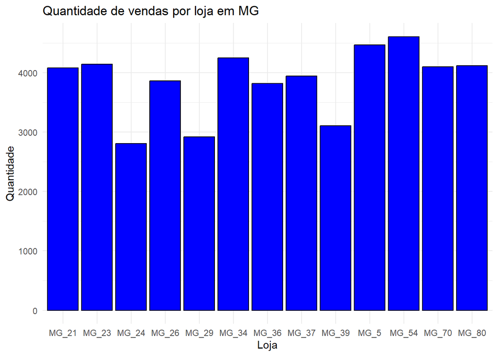

```r
# Quantidade de vendas por loja em MG

data <- dados1 %>%
  mutate(estado = substr(cod_loja, 1, 2))

data_mg <- filter(data, estado == 'MG')

ggplot(data_mg, aes(x = cod_loja)) +
  geom_bar(stat = "count", fill = "blue", color = "black") +
  theme_minimal() +
  labs(title = "Quantidade de vendas por loja em MG", x = "Loja", y = "Quantidade")
```

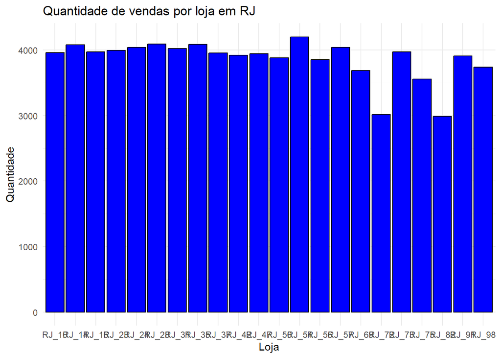

```r
# Quantidade de vendas por loja em RJ

data_rj <- filter(data, estado == 'RJ')

ggplot(data_rj, aes(x = cod_loja)) +
  geom_bar(stat = "count", fill = "blue", color = "black") +
  theme_minimal() +
  labs(title = "Quantidade de vendas por loja em RJ", x = "Loja", y = "Quantidade")
```

- Aqui adicionei também um ranking com a quantidade de vendas por loja em SP

```r
# Quantidade de vendas por loja em SP

data_sp <- filter(data, estado == 'SP')

ranking_sp <- data_sp %>%
  group_by(cod_loja) %>%
  summarise(Quantidade = n(), .groups = 'drop') %>%
  arrange(desc(Quantidade))

print(head(ranking_sp))
```

```
## # A tibble: 6 × 2
##   cod_loja                  Quantidade
##   <chr>                          <int>
## 1 SP Interior_90                  4962
## 2 SP Capital Sul_29               4886
## 3 SP Capital Leste/Oeste_39       4708
## 4 SP Capital Leste/Oeste_66       4705
## 5 SP Capital Centro_80            4654
## 6 SP Capital Leste/Oeste_85       4484
```

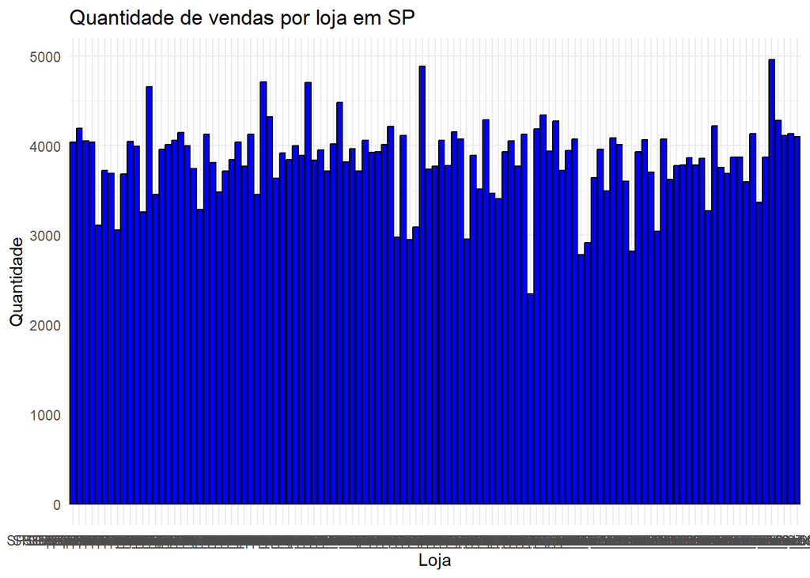

```r
ggplot(data_sp, aes(x = cod_loja)) +
  geom_bar(stat = "count", fill = "blue", color = "black") +
  theme_minimal() +
  labs(title = "Quantidade de vendas por loja em SP", x = "Loja", y = "Quantidade")
```

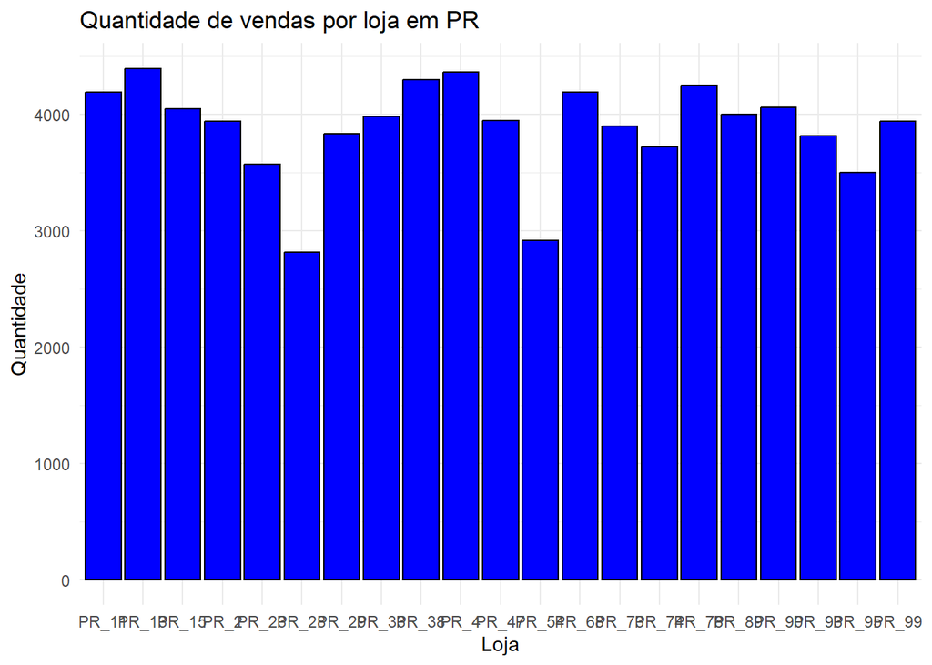

```r
# Quantidade de vendas por loja em PR

data_pr <- filter(data, estado == 'PR')

ggplot(data_pr, aes(x = cod_loja)) +
  geom_bar(stat = "count", fill = "blue", color = "black") +
  theme_minimal() +
  labs(title = "Quantidade de vendas por loja em PR", x = "Loja", y = "Quantidade")
```

```r
ranking_pr <- data_pr %>%
  group_by(cod_loja) %>%
  summarise(Quantidade = n(), .groups = 'drop') %>%
  arrange(desc(Quantidade))

print(head(ranking_pr))
```

```
## # A tibble: 6 × 2
##   cod_loja Quantidade
##   <chr>         <int>
## 1 PR_13          4394
## 2 PR_4           4363
## 3 PR_38          4299
## 4 PR_78          4249
## 5 PR_68          4191
## 6 PR_11          4190
```

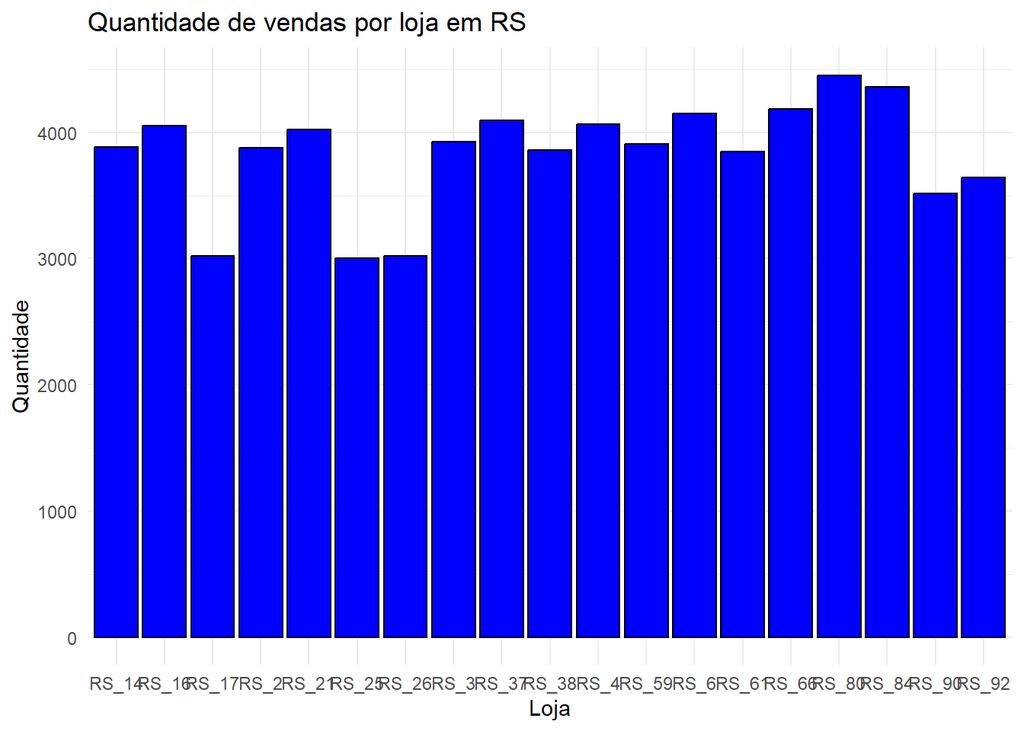

```r
# Quantidade de vendas por loja em RS

data_rs <- filter(data, estado == 'RS')

ggplot(data_rs, aes(x = cod_loja)) +
  geom_bar(stat = "count", fill = "blue", color = "black") +
  theme_minimal() +
  labs(title = "Quantidade de vendas por loja em RS", x = "Loja", y = "Quantidade")
```

```r
ranking_rs <- data_rs %>%
  group_by(cod_loja) %>%
  summarise(Quantidade = n(), .groups = 'drop') %>%
  arrange(desc(Quantidade))

print(head(ranking_rs))
```

```
## # A tibble: 6 × 2
##   cod_loja Quantidade
##   <chr>         <int>
## 1 RS_80          4453
## 2 RS_84          4360
## 3 RS_66          4186
## 4 RS_6           4149
## 5 RS_37          4093
## 6 RS_4           4065
```

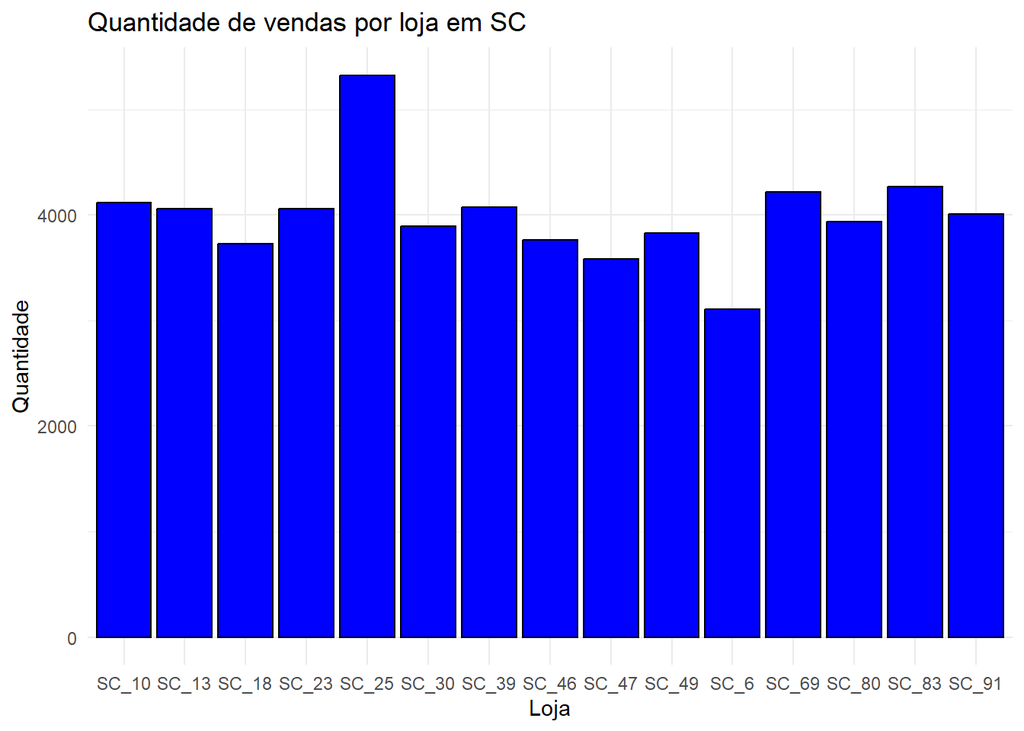

```r
data_sc <- filter(data, estado == 'SC')

ggplot(data_sc, aes(x = cod_loja)) +
  geom_bar(stat = "count", fill = "blue", color = "black") +
  theme_minimal() +
  labs(title = "Quantidade de vendas por loja em SC", x = "Loja", y = "Quantidade")
```

```r
ranking_sc <- data_sc %>%
  group_by(cod_loja) %>%
  summarise(Quantidade = n(), .groups = 'drop') %>%
  arrange(desc(Quantidade))

print(head(ranking_sc))
```

```
## # A tibble: 6 × 2
##   cod_loja Quantidade
##   <chr>         <int>
## 1 SC_25          5325
## 2 SC_83          4272
## 3 SC_69          4221
## 4 SC_10          4117
## 5 SC_39          4071
## 6 SC_23          4059
```

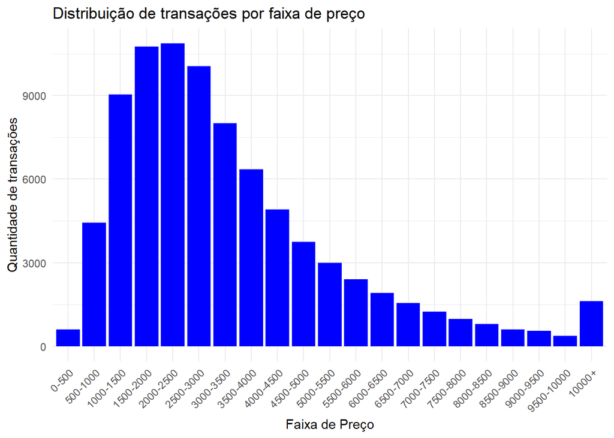

```r
data_agrupada <- data %>%
  group_by(cod_transacao) %>%
  summarise(
    total_quantidade = sum(quantidade),
    total_preco = sum(preco),
    .groups = 'drop'
  )

# Ajustando o valor máximo e definindo intervalos

max_valor <- max(data_agrupada$total_preco, na.rm = TRUE)

intervalo <- 500
max_valor_ajustado <- ceiling(max_valor / intervalo) * intervalo

# Categorizando os preços em faixas

data_agrupada <- data_agrupada %>%
  mutate(faixa_preco = case_when(
    total_preco > 10000 ~ "10000+",
    TRUE ~ cut(total_preco,
               breaks = seq(0, max_valor_ajustado, by = intervalo),
               include.lowest = TRUE,
               right = FALSE,
               labels = paste(seq(0, max_valor_ajustado - intervalo, by = intervalo),
                              seq(intervalo, max_valor_ajustado, by = intervalo), sep = "-"))
  ))

# Transformando faixa_preco em fator e ordenando níveis

data_agrupada <- data_agrupada %>%
  mutate(faixa_preco = factor(faixa_preco, levels = c(paste(seq(0, max_valor_ajustado - intervalo, by = intervalo),
                                                            seq(intervalo, max_valor_ajustado, by = intervalo), sep = "-"),
                                                     "10000+")))

# Contagem de transações por faixa de preço

contagem_faixa <- data_agrupada %>%
  count(faixa_preco)

# Criando o gráfico de colunas

ggplot(contagem_faixa, aes(x = faixa_preco, y = n)) +
  geom_col(fill = "blue") +
  labs(x = "Faixa de Preço", y = "Quantidade de transações", title = "Distribuição de transações por faixa de preço") +
  theme_minimal() +
  theme(axis.text.x = element_text(angle = 45, hjust = 1))
```

```r
Q1 <- quantile(data_agrupada$total_preco, 0.25)
Q3 <- quantile(data_agrupada$total_preco, 0.75)
IQR <- Q3 - Q1

# Definindo os limites para outliers

lower_bound <- Q1 - 1.5 * IQR
upper_bound <- Q3 + 1.5 * IQR

# Identificando os valores específicos que são considerados outliers

outliers <- data_agrupada$total_preco[data_agrupada$total_preco < lower_bound | data_agrupada$total_preco > upper_bound]

# Resultados

cat("Lower Bound for Outliers:", lower_bound, "\n")
```

```
## Lower Bound for Outliers: -1824.184
```

```r
cat("Upper Bound for Outliers:", upper_bound, "\n")
```

```
## Upper Bound for Outliers: 7912.829
```

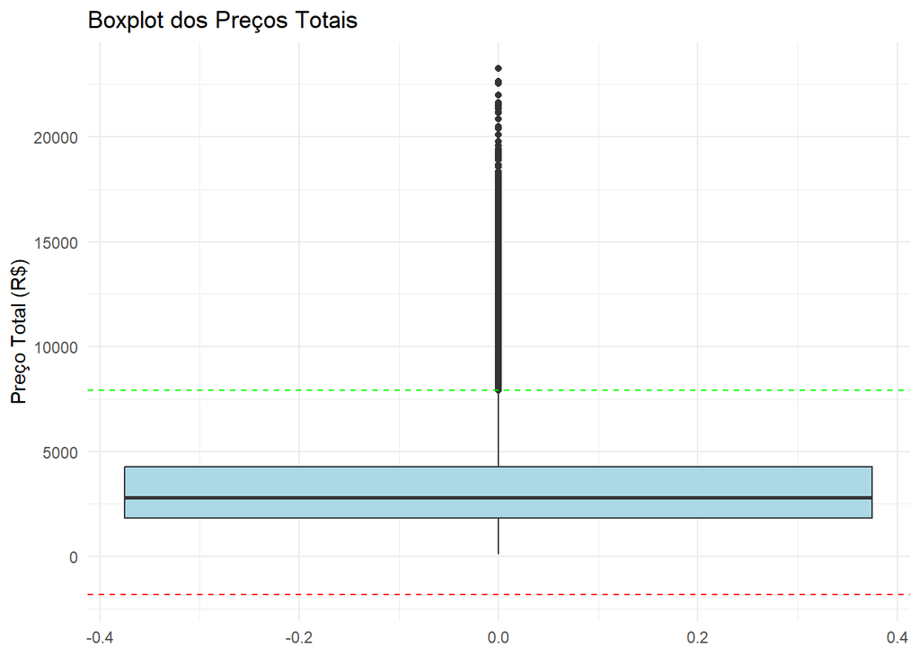

```r
ggplot(data_agrupada, aes(y = total_preco)) +
  geom_boxplot(fill = "lightblue") +
  labs(title = "Boxplot dos Preços Totais", y = "Preço Total (R$)") +
  theme_minimal() +
  geom_hline(yintercept = lower_bound, color = "red", linetype = "dashed") +

  geom_hline(yintercept = upper_bound, color = "green", linetype = "dashed")
```

O boxplot dos preços totais mostra que a maioria das transações possui preços relativamente moderados, Porém, há uma quantidade significativa de outliers representados pelos pontos acima do whisker superior, sugerindo a presença de várias transações com valores muito mais altos que o restante.

É interessante analisar o porque esses outliers estão conseguindo números tão elevados, isso pode ser algo que pode ser usado como exemplo para outras lojas.

## 4. Análise bivariada

### Visualização dos gráficos do valor das transações por estado

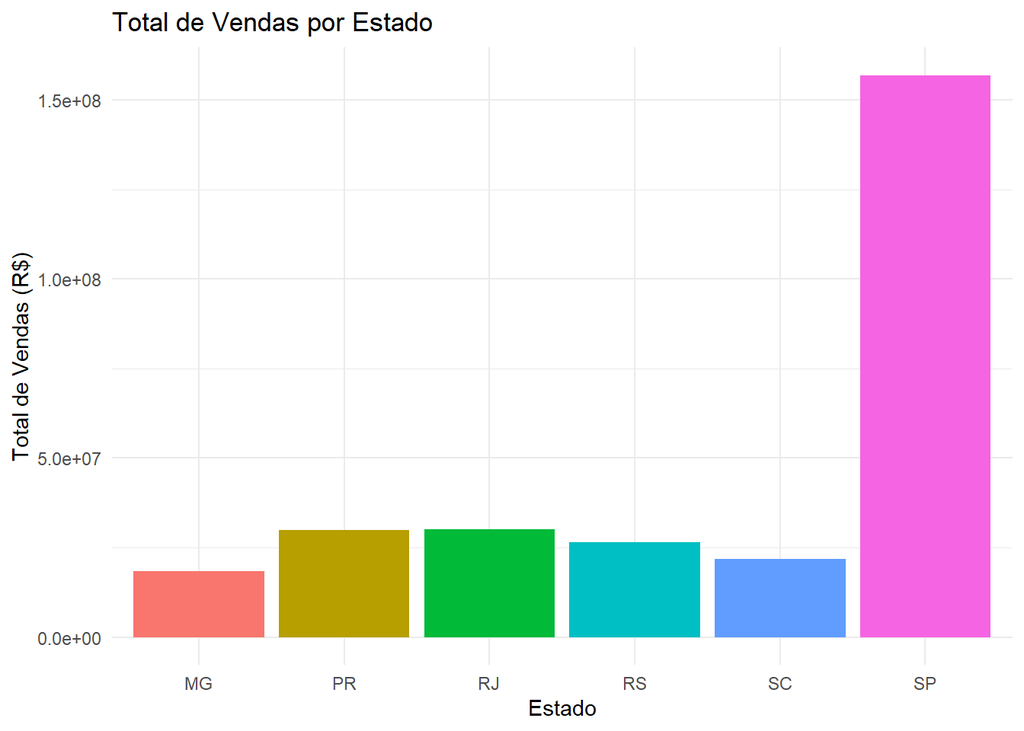

```r
data$estado <- str_extract(data$cod_loja, "^[A-Z]{2}")

# Agregando os dados para somar os valores por estado

dados_agregados <- data %>%
  group_by(estado) %>%
  summarise(total_vendas = sum(preco, na.rm = TRUE))

# Criando o gráfico de colunas

ggplot(dados_agregados, aes(x = estado, y = total_vendas, fill = estado)) +
  geom_col() +
  labs(title = "Total de Vendas por Estado", x = "Estado", y = "Total de Vendas (R$)") +
  theme_minimal() +
  theme(legend.position = "none")
```

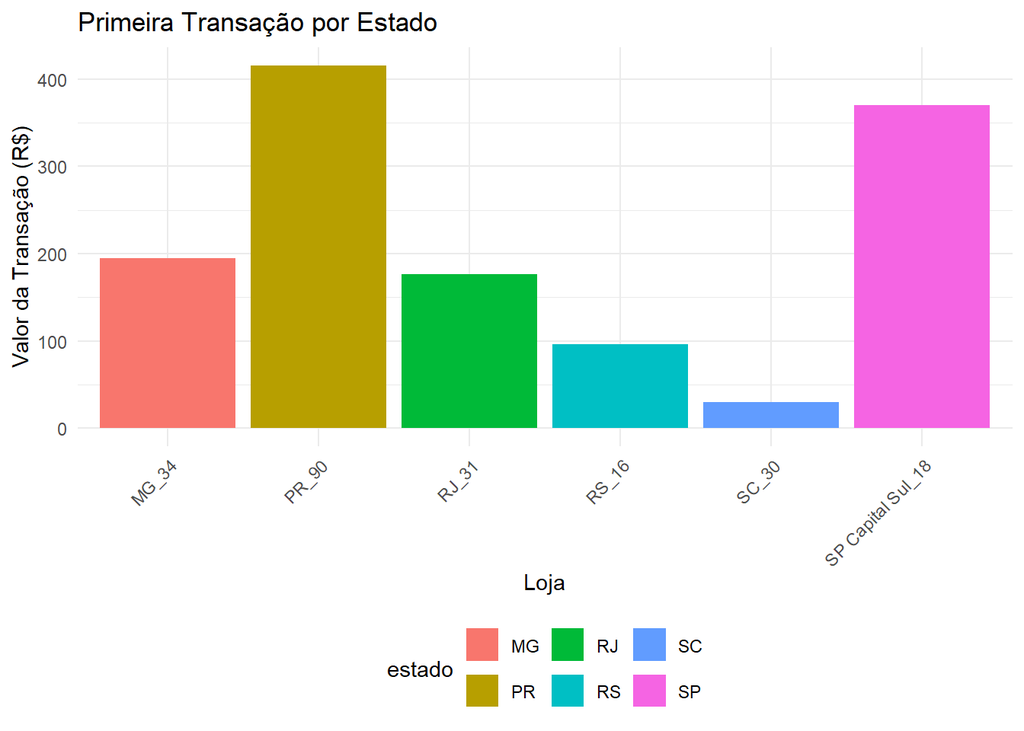

```r
# Extraindo a primeira linha de cada DataFrame

first_trans_mg <- data_mg %>% slice(1)
first_trans_rj <- data_rj %>% slice(1)
first_trans_sp <- data_sp %>% slice(1)
first_trans_sc <- data_sc %>% slice(1)
first_trans_pr <- data_pr %>% slice(1)
first_trans_rs <- data_rs %>% slice(1)


# Combinando as primeiras transações em um único DataFrame

first_trans_all <- bind_rows(first_trans_mg, first_trans_rj, first_trans_sp, first_trans_sc, first_trans_pr, first_trans_rs)

# Criando o gráfico de barras

ggplot(first_trans_all, aes(x = cod_loja, y = preco, fill = estado)) +
  geom_col() +
  labs(title = "Primeira Transação por Estado", x = "Loja", y = "Valor da Transação (R$)") +
  theme_minimal() +
  theme(axis.text.x = element_text(angle = 45, hjust = 1), legend.position = "bottom")
```

### Análise de correlação

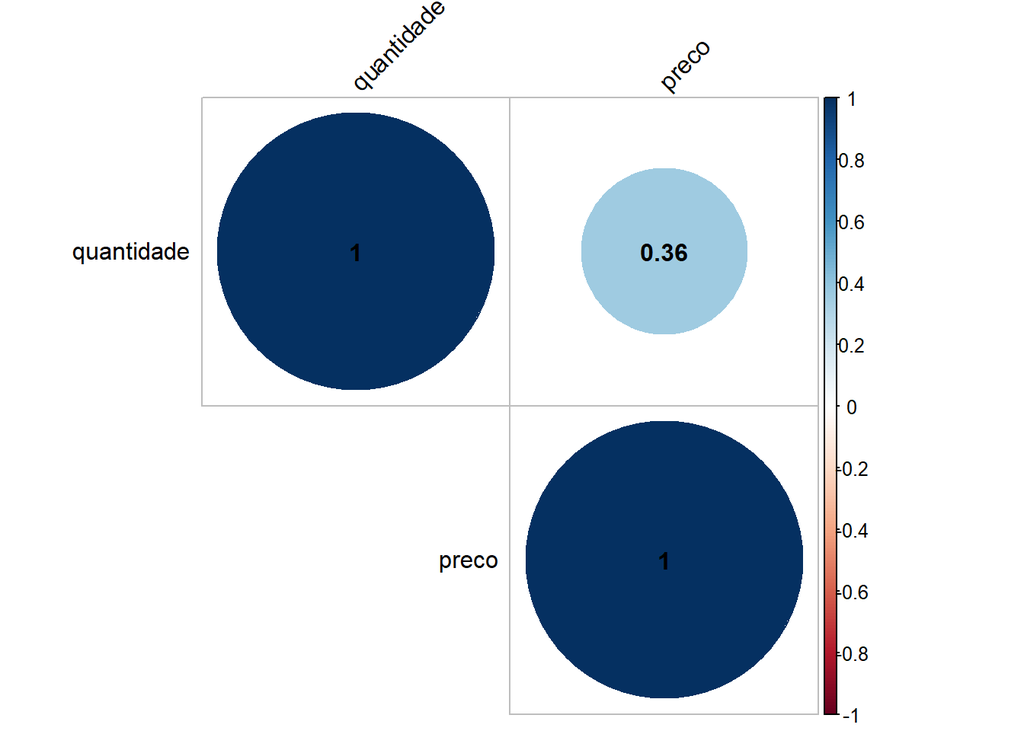

```r
numeric_data <- data %>%
  select(quantidade, preco)

# Calculando a matriz de correlação

cor_matrix <- cor(numeric_data)

# Visualizando a matriz de correlação

corrplot(cor_matrix, method = "circle", type = "upper", order = "hclust",
         tl.col = "black", tl.srt = 45,
         addCoef.col = "black")
```

Há uma relação entre preço e quantidade.

## 5. Análise multivariada

### PCA

```r
pca_result <- prcomp(numeric_data, scale. = TRUE)

# Visualizando o resumo dos resultados do PCA

summary(pca_result)
```

```
## Importance of components:
##                           PC1    PC2
## Standard deviation     1.1655 0.8009
## Proportion of Variance 0.6792 0.3208
## Cumulative Proportion  0.6792 1.0000
```

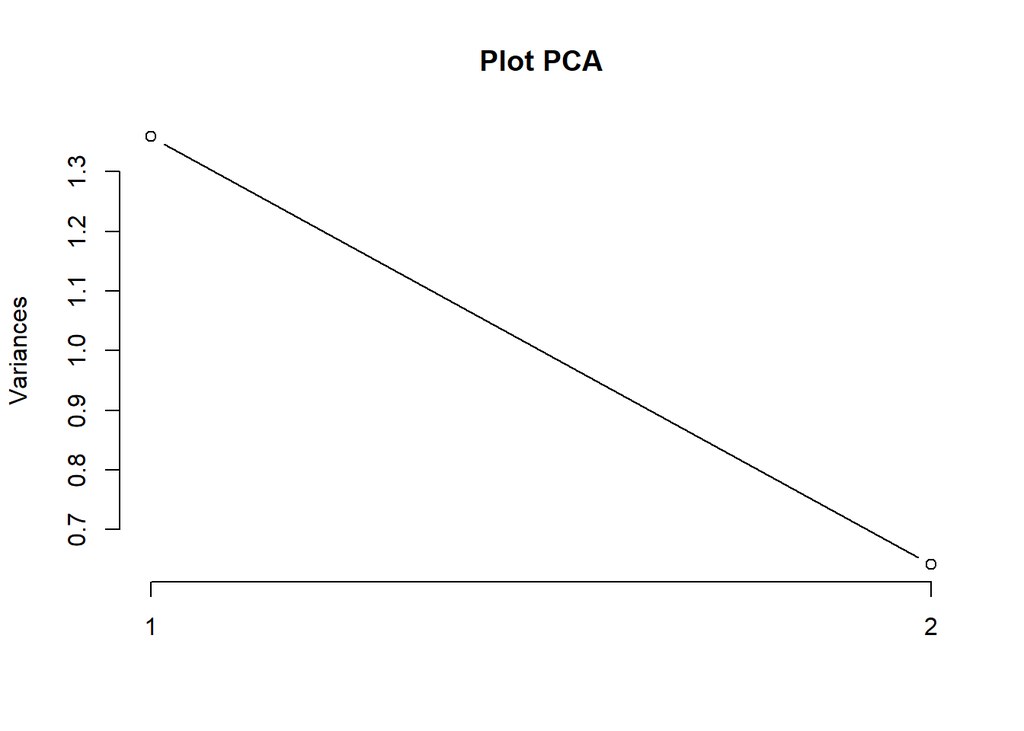

```r
plot(pca_result, type = "l", main = "Plot PCA")
```

O primeiro componente principal é dominante tendo 67% de proporção cumulativa, indicando que uma única dimensão é suficiente para capturar a maior parte da informação nos dados. Podendo assim, reduzir a dimensionalidade do dataframe.

## Classificação das melhores lojas no mês atual

```r
data_maio <- dados1 %>%
  filter(format(as.Date(data, format = "%Y-%m-%d"), "%Y-%m") == "2024-05")

# Agrupar por loja e calcular a receita total

ranking_lojas <- data_maio %>%
  group_by(cod_loja) %>%
  summarise(receita_total = sum(preco, na.rm = TRUE)) %>%
  arrange(desc(receita_total))

# Selecionar as 10 lojas com maior receita

top_10_lojas <- head(ranking_lojas, 10)

# Visualizar o resultado

print(top_10_lojas)
```

```
## # A tibble: 10 × 2
##    cod_loja                  receita_total
##    <chr>                             <dbl>
##  1 SC_25                           393847.
##  2 SP Capital Leste/Oeste_39       385890.
##  3 MG_54                           385440.
##  4 SP Capital Leste/Oeste_66       363979.
##  5 RJ_54                           354128.
##  6 SP Capital Centro_80            349977.
##  7 SP Capital Sul_16               348774.
##  8 RS_21                           348162.
##  9 MG_5                            344516.
## 10 SP Capital Leste/Oeste_48       340713.
```

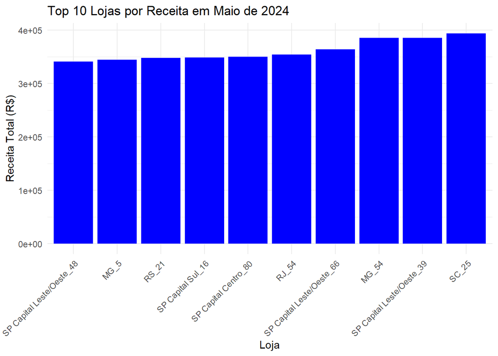

```r
ggplot(top_10_lojas, aes(x = reorder(cod_loja, receita_total), y = receita_total)) +
  geom_col(fill = "blue") +  # cor única para todas as barras
  labs(title = "Top 10 Lojas por Receita em Maio de 2024", x = "Loja", y = "Receita Total (R$)") +
  theme_minimal() +
  theme(axis.text.x = element_text(angle = 45, hjust = 1))
```

## 6. Conclusão e Discussão

### Discussão sobre limitações e possíveis melhorias

Algumas limitações que pude perceber foi, por exemplo, a exclusão de variáveis potencialmente influentes, como detalhes de promoções/mudanças de preço ou localizações específicas das lojas, isso limitou um pouco uma análise mais profunda dos insights obtidos. Além disso, o foco em um único mês pode não capturar variações e tendências mais amplas que apenas análises de longo prazo poderiam revelar.

Para futuras análises, uma possível melhoria seria expandir o conjunto de dados para incluir mais variáveis que possam enriquecer a análise. Um estudo mais prolongado poderia ajudar a identificar tendências sazonais e padrões de longo prazo nas vendas. A criação de modelos preditivos baseados nos dados atuais poderia facilitar a previsão de tendências futuras, auxiliando na tomada de decisões estratégicas mais informadas